# Investigation of Policy and Legislative Actions for the Reduction of Fatal Traffic Incidents in Relation to Alcohol and Socio-Economic Factors

Keith Mitchell, Pin-Hsun Mao, Seyoung Jung, Yige Luo

2/12/2021

# Introduction

Fatalities related to traffic is a point of interest for policy makers at the state and federal level, which could likely be associated with various alcohol, societal, religional, and socio-economic factors in these regions.

Traffic incidents are the number one source of deaths for persons in the age range of 1-34 and 41% of fatal crashes associate with drinking (Hingson 1996) Alcohol is known to alter driving performance, and the various factors surrounding alcohol legislation as well as other societal factors is likely to modify alcohol usage by pupils and therefore traffic fatalities (Zhao, Zhang, and Rong 2014). In addition, a variety of socio-economic factors have also been previously studied showing that traffic accidents for certain economic levels are associated with increases in mortality (Sehat et al. 2012). Legislation and policy can help to diminish the effect of alcohol related incidences as well as lower the effect of social and economic factors. Therefore, further investigation into these potential solutions is warranted.

The following are some helpful research studies. The contents of these studies relate to the contents briefly mentioned above:

- [Study of the Effects of Alcohol on Drivers and Driving Performance on Straight Road](https://www.hindawi.com/journals/mpe/2014/607652/)
- [Preventative Legislation for Drinking and Driving](https://www.ncbi.nlm.nih.gov/pmc/articles/PMC6876524/)

# Background

Data was collected for 48 states in the United States, with Alaska and Hawaii being the two excluded states. The traffic fatality data was gathered from the US Department of Transportation Fatal Accident Reporting System (“Fatality Analysis Reporting System (FARS)” 2016) which is a census conducted nationwide to provide the public with data related to the traffic crashes. The data set contains 336 entries and 34 variables. The number of entries is 336, since there is an entry for each of the 48 states for the years 1982 through 1988 (“Fatalities” n.d.).

- Explanation of variables found here: Fatalities
- Info about the FARS: [Fatality Analysis Reporting System](https://www.nhtsa.gov/research-data/fatality-analysis-reporting-system-fars)

Given the goal of the analysis is to help determine policy and legislative changes that would be of interest to legislators at the state and federal level. Some policies of interest present in the dataset include the legal drinking age (ranging from 18-21), presence of a preliminary breath test law, as well as mandatory jail sentence for alcohol induced traffic accidents. Other data available for potential exploration are spirits consumption score for regions, which is a measure of high percentage alcohol content intake (>30% alcohol by volume (ABV). In addition, the tax on a case of beer is provided to see if taxation rates can influence fatal traffic incidents.

There is interest in further exploring variables related to the amount of travel in a region, measured in average miles per driver. In addition, other socio-economic factors like the amount of young drivers and income with regards to traffic incidents will be explored. Some of the response variables of interest are the fatality rate which can be obtained using the total vehicle fatalities after normalizing by population size. Similar methods can be used to explore the overall rates for the age groups 15-17, 18-20, and 21-24.

# Methods/Results

## Descriptive Analysis

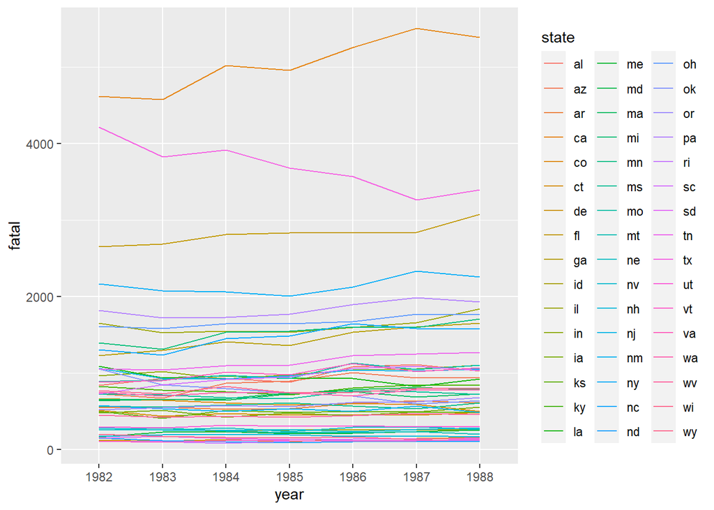

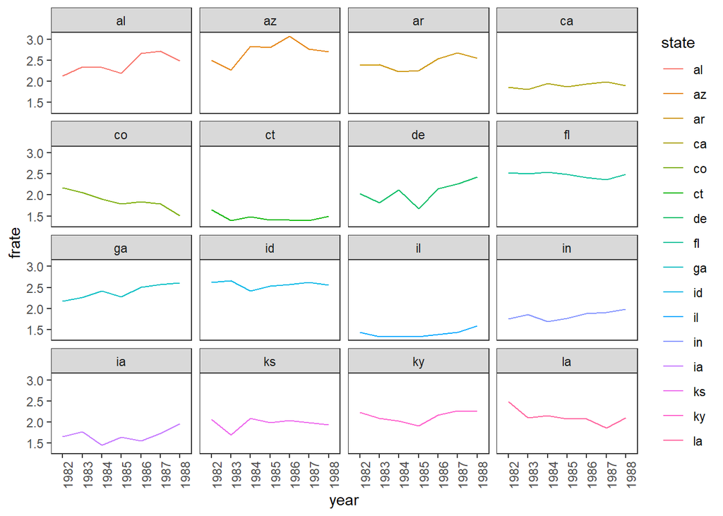

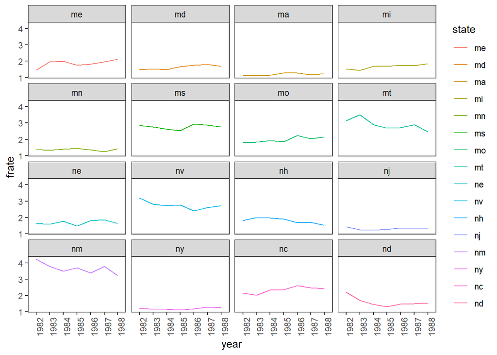

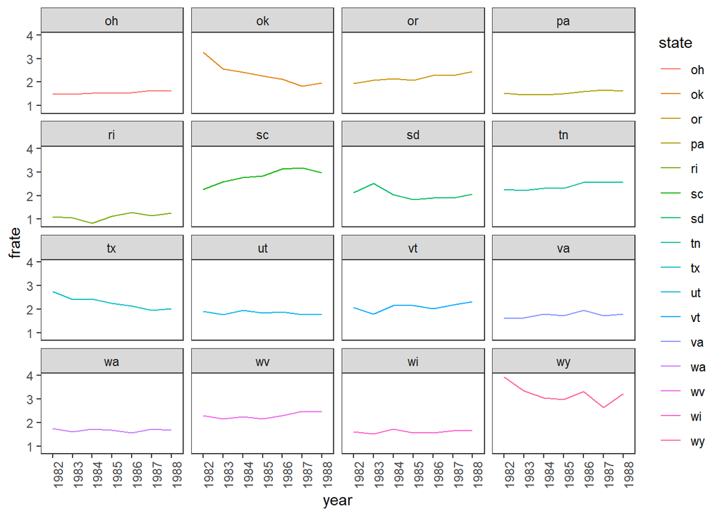

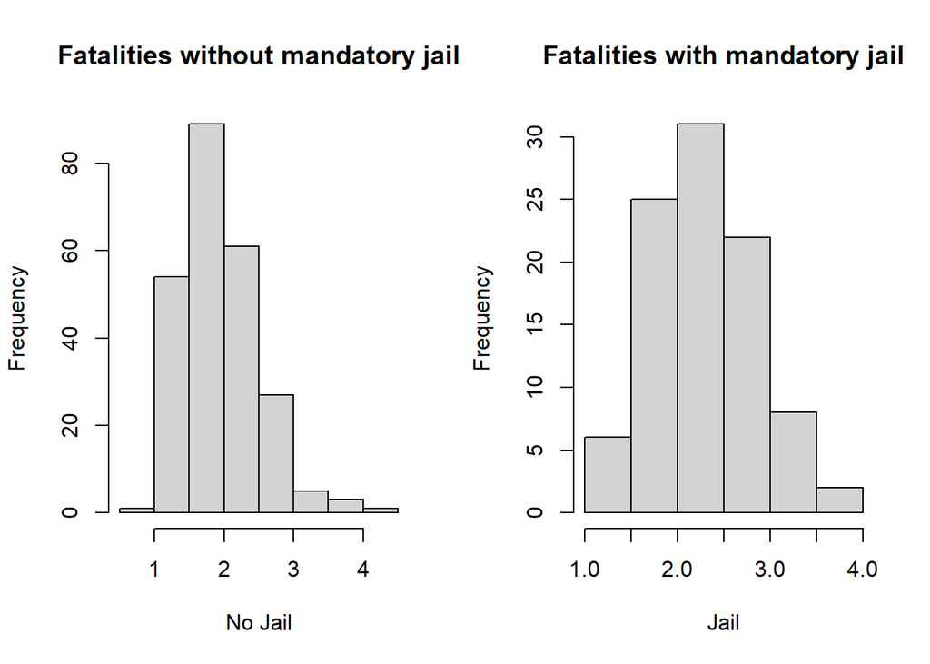

However, because the populations of different states vary, we also use the ratio of the total number of fatalities over the population of the state to plot histograms again, and we find that the ratio in the histogram of mandatory jail sentence is larger than that that in the histogram without jail sentence. So, the population of each state may be affecting our analysis.

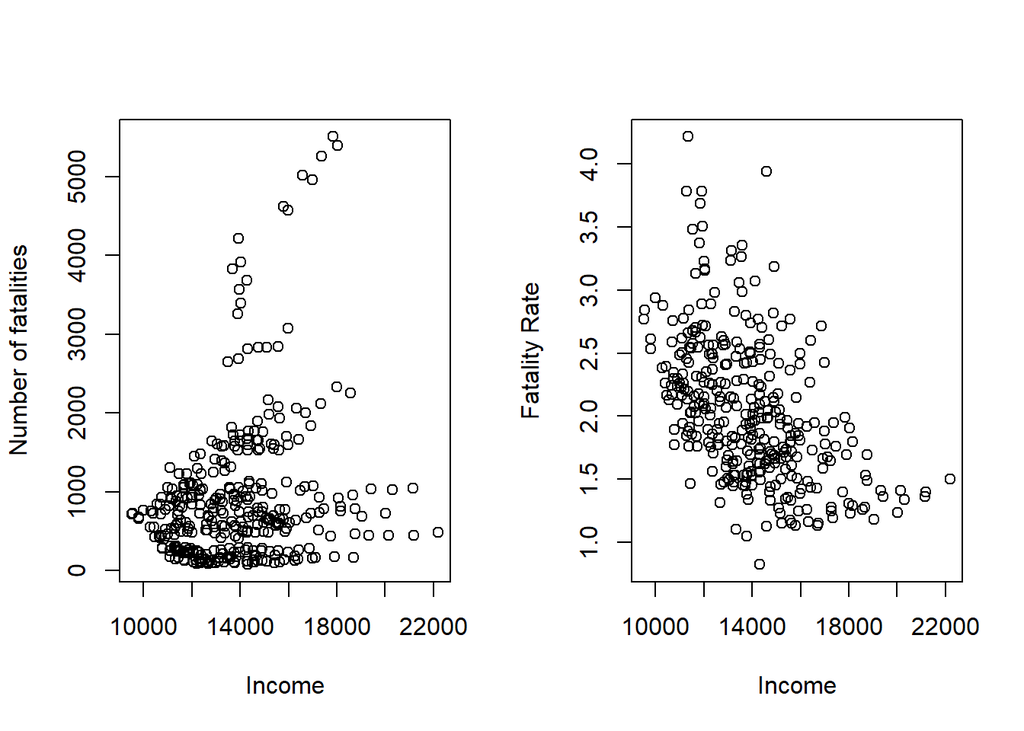

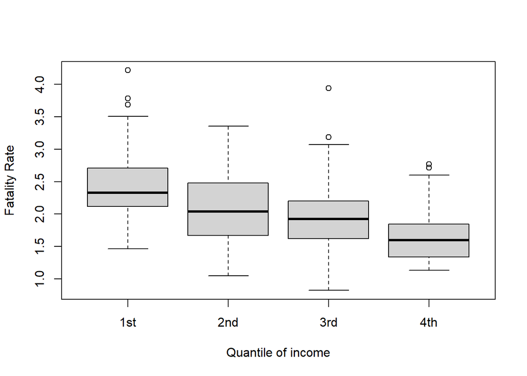

We use quantiles to reclassify income, and plot the two-way box plot between income and the fatality rate. We can observe that the third and fourth quantiles of incomes appear to havehave lower average fatality rate.

| **Characteristic** | **1st**, N = 84<sup>1</sup> | **2nd**, N = 84<sup>1</sup> | **3rd**, N = 84<sup>1</sup> | **4th**, N = 84<sup>1</sup> | **p-value**<sup>2</sup> |
| --- | --- | --- | --- | --- | --- |
| frate | 2.463946 (0.521244, 2.326700, 0.582645) | 2.094255 (0.529211, 2.038250, 0.798775) | 1.957469 (0.500966, 1.921650, 0.566997) | 1.646105 (0.400897, 1.595370, 0.504353) | <0.001 |

<sup>*1*</sup> Mean (SD, Median, IQR) <sup>*2*</sup> Kruskal-Wallis rank sum test

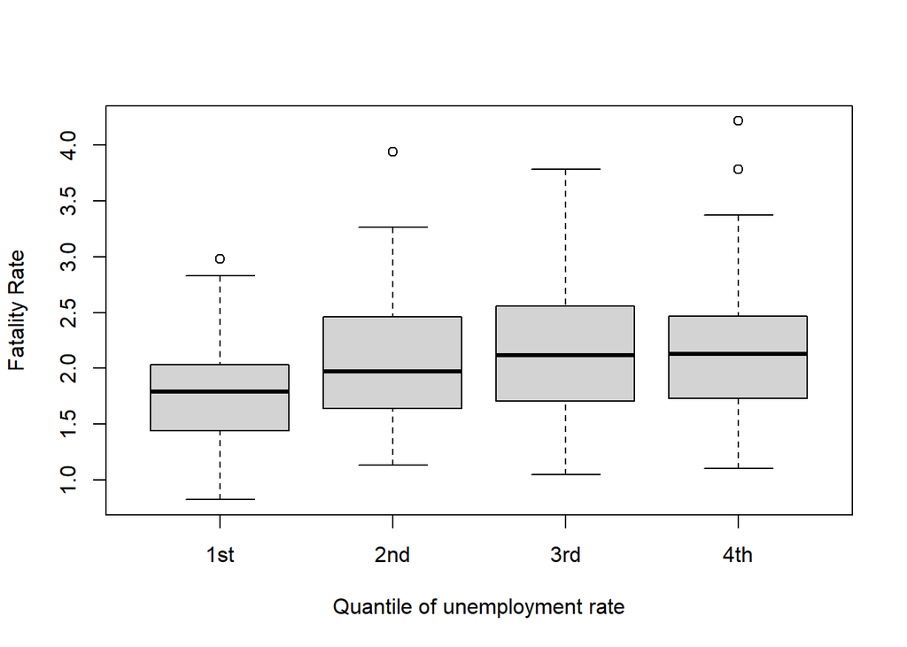

| **Characteristic** | **1st**, N = 84<sup>1</sup> | **2nd**, N = 86<sup>1</sup> | **3rd**, N = 87<sup>1</sup> | **4th**, N = 79<sup>1</sup> | **p-value**<sup>2</sup> |
| --- | --- | --- | --- | --- | --- |
| frate | 1.796898 (0.433528, 1.787740, 0.582680) | 2.072680 (0.569494, 1.972620, 0.814467) | 2.150567 (0.617650, 2.114340, 0.851595) | 2.143037 (0.577148, 2.128360, 0.735540) | <0.001 |

<sup>*1*</sup> Mean (SD, Median, IQR) <sup>*2*</sup> Kruskal-Wallis rank sum test

```
##    year        state          pop               fatal            income
##  1982:48   al     :  7   Min.   :  479000   Min.   :  79.0   Min.   : 9514
##  1983:48   az     :  7   1st Qu.: 1545251   1st Qu.: 293.8   1st Qu.:12086
##  1984:48   ar     :  7   Median : 3310503   Median : 701.0   Median :13763
##  1985:48   ca     :  7   Mean   : 4930272   Mean   : 928.7   Mean   :13880
##  1986:48   co     :  7   3rd Qu.: 5751735   3rd Qu.:1063.5   3rd Qu.:15175
##  1987:48   ct     :  7   Max.   :28314028   Max.   :5504.0   Max.   :22193
##  1988:48   (Other):294
##      unemp            miles          beertax         youngdrivers
##  Min.   : 2.400   Min.   : 4576   Min.   :0.04331   Min.   :0.07314
##  1st Qu.: 5.475   1st Qu.: 7183   1st Qu.:0.20885   1st Qu.:0.17037
##  Median : 7.000   Median : 7796   Median :0.35259   Median :0.18539
##  Mean   : 7.347   Mean   : 7891   Mean   :0.51326   Mean   :0.18593
##  3rd Qu.: 8.900   3rd Qu.: 8504   3rd Qu.:0.65157   3rd Qu.:0.20219
##  Max.   :18.000   Max.   :26148   Max.   :2.72076   Max.   :0.28163
##
##    jail     breath    service
##  no  :241   no :181   no  :273
##  yes : 94   yes:155   yes : 62
##  NA's:  1             NA's:  1
##
##
##
##
```

```
##    state year jail service
## 28    ca 1988 <NA>    <NA>
```

Notice California has missing values in `jail` and `service` only in year 1988. We create a new variable “frate” which is the the number of fatalities per 10000 residents.

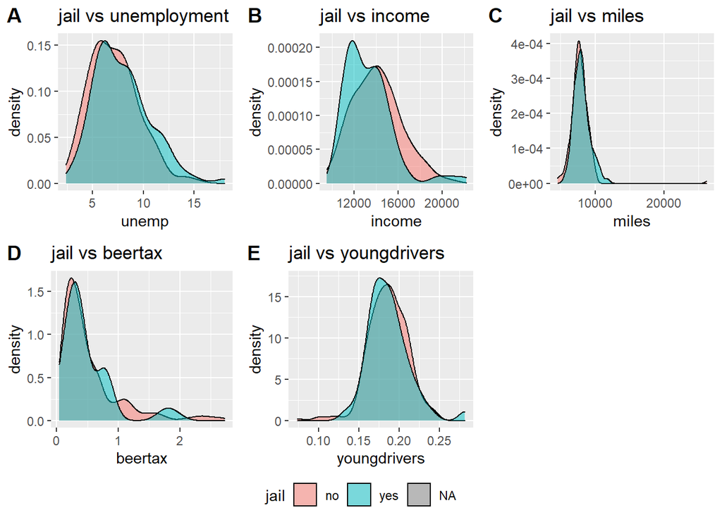

- unemployment does not seem to strongly impact the propensity of being assigned to treatment (jail = yes) or control (jail = no) group.
- It seems that income impacts the propensity of being assigned to treatment (jail = yes) or control (jail = no) group. Therefore income should be included in the selection model.
- mileage driven per person does not seem to strongly impact the propensity of being assigned to treatment (jail = yes) or control (jail = no) group.
- beertax does not seem to strongly impact the propensity of being assigned to treatment (jail = yes) or control (jail = no) group.
- percent of young drivers does not seem to strongly impact the propensity of being assigned to treatment (jail = yes) or control (jail = no) group.

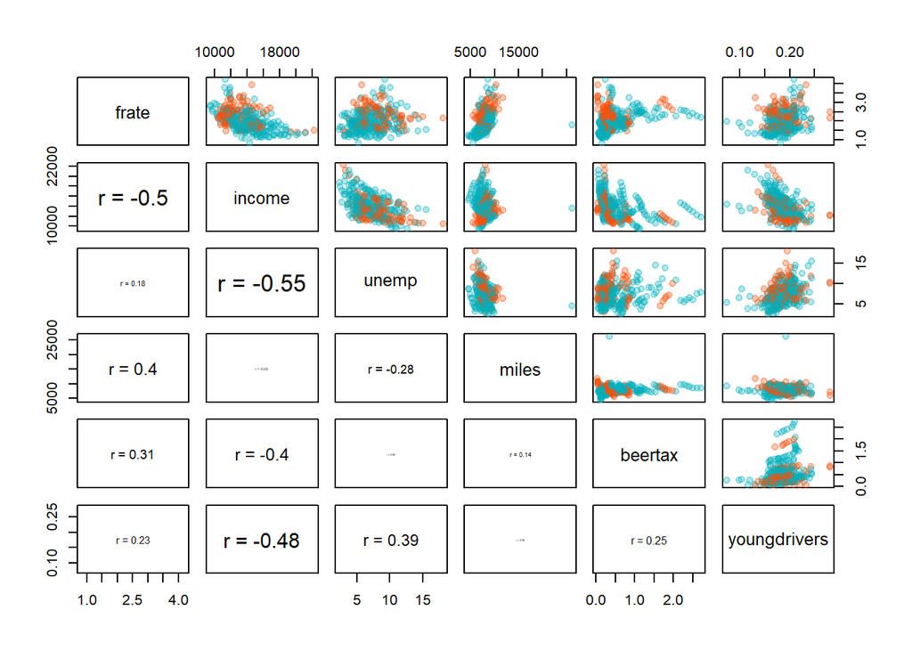

Independent variables chosen based on the degree of correlation with “frate”, and we start by building a tentative outcome model without the use of propensity scores.

## Predictive/Inferential Analysis

The package lme4 for Fitting Linear Mixed-Effects Models was utilized to allow for both fixed and random effects. Due to multiple observations for each state from the years 1982-1988 there is inherent non-randomness in our data. Therefore, this analysis is interested in variability for each state and its relative fatality rate and this is preferred to aggregation of the data as it does not properly utilize all of the data.

- [lme4 Package Documentation](https://cran.r-project.org/web/packages/lme4/vignettes/lmer.pdf)

The Linear Mixed Model follows the following form:
$$y = \textbf{X}\beta + Z\mu + \epsilon$$

- $y$ and $\epsilon$ are both nx1 vectors representing the dependent variable and the residuals. The residuals refer to the amount of the dependent variable, in this case fatality rate, that is not explained by the model.
- $n$ is the number of observations in the dataset, in this case 336.
- $\textbf{X}$ is an $n$ x $p$ matrix where there are $p$ predictor variables in the model.
- $\textbf{Z}$ is the random effects design matrix of size $N$ x $qJ$ where there are $q$ random effects of interest and $J$ groups. (Vasishth and Broe 2011)

### Model 1 (treatment (jail = yes) and control (jail = no))

|  | Estimate | Std. Error | df | t value | Pr(>\|t\|) |
| --- | --- | --- | --- | --- | --- |
| (Intercept) | 1.862 | 0.194 | 267.818 | 9.624 | 0.000 |
| jailyes | 0.027 | 0.063 | 325.216 | 0.424 | 0.672 |
| rescale(unemp) | -0.765 | 0.157 | 314.847 | -4.884 | 0.000 |
| rescale(income) | 0.029 | 0.251 | 327.494 | 0.116 | 0.908 |
| rescale(beertax) | -0.207 | 0.349 | 132.855 | -0.594 | 0.554 |
| rescale(youngdrivers) | 0.730 | 0.143 | 284.869 | 5.104 | 0.000 |
| rescale(miles) | 0.290 | 0.211 | 282.448 | 1.374 | 0.170 |

We found a non-significant treatment effect, as the factor level jailyes is not statistically significant at p = 0.05. However, the covariates `unemp` and `youngdrivers` are statistically significant at p < 0.001.

Based on our exploratory data analysis and group discussion, we assume that the variables `unemp`, `income`, `beertax`, `youngdrivers` and `miles` have an influence on the assignment to either the control (jail = no) or the treatment (jail = yes) group.

Next we performed a balance analysis, trying to assess the degree of bias during assignment to treatment and control groups, before the use of propensity scores.

#### Balance analysis before estimating propensity scores:

- jail vs. miles

  |  | Estimate | Std. Error | t value | Pr(>\|t\|) |
  | --- | --- | --- | --- | --- |
  | (Intercept) | 7822.8809 | 95.06904 | 82.28631 | 0.00000 |
  | jailyes | 235.0653 | 179.47237 | 1.30976 | 0.19118 |

- jail vs. income

  |  | Estimate | Std. Error | t value | Pr(>\|t\|) |
  | --- | --- | --- | --- | --- |
  | (Intercept) | 14078.754 | 143.1639 | 98.34011 | 0.0000 |
  | jailyes | -752.018 | 270.2664 | -2.78251 | 0.0057 |

- jail vs. beertax

  |  | Estimate | Std. Error | t value | Pr(>\|t\|) |
  | --- | --- | --- | --- | --- |
  | (Intercept) | 0.52622 | 0.03081 | 17.07806 | 0.0000 |
  | jailyes | -0.04165 | 0.05817 | -0.71598 | 0.4745 |

- jail vs. youngdrivers

  |  | Estimate | Std. Error | t value | Pr(>\|t\|) |
  | --- | --- | --- | --- | --- |
  | (Intercept) | 0.18587 | 0.00160 | 116.05429 | 0.00000 |
  | jailyes | 0.00062 | 0.00302 | 0.20575 | 0.83712 |

- jail vs. unemployment

  |  | Estimate | Std. Error | t value | Pr(>\|t\|) |
  | --- | --- | --- | --- | --- |
  | (Intercept) | 7.12448 | 0.16180 | 44.03133 | 0.00000 |
  | jailyes | 0.81382 | 0.30546 | 2.66426 | 0.00809 |

|  | Estimate | Std. Error | z value | Pr(>\|z\|) |
| --- | --- | --- | --- | --- |
| (Intercept) | 0.85560 | 2.31333 | 0.36986 | 0.71149 |
| unemp | 0.10654 | 0.06508 | 1.63705 | 0.10162 |
| income | -0.00017 | 0.00008 | -1.99665 | 0.04586 |
| beertax | -0.51887 | 0.31928 | -1.62513 | 0.10413 |
| youngdrivers | -6.64806 | 5.66580 | -1.17337 | 0.24065 |
| miles | 0.00015 | 0.00010 | 1.54600 | 0.12211 |

As expected from descriptive analysis, we found that covariate `income` significantly impact the assignment to treatment or control group at p < 0.05. Note that the significance level of `unemp` does not reach p = 0.1, probably due to its strong negative correlation with `income` (r = -0.55) and therefore does not contribute more information when `income` is included in the model. We decide to keep all 5 variables in the selection model regardless of their significance level, as advocated by Caliendo and Kopeinig (2008).

|  | Estimate | Std. Error | df | t value | Pr(>\|t\|) |
| --- | --- | --- | --- | --- | --- |
| (Intercept) | 1.74075 | 0.18929 | 263.2185 | 9.19633 | 0.00000 |
| jailyes | 0.01919 | 0.06513 | 327.3781 | 0.29470 | 0.76841 |
| rescale(unemp) | -0.72645 | 0.15375 | 315.1683 | -4.72497 | 0.00000 |
| rescale(income) | 0.15680 | 0.25165 | 325.8747 | 0.62310 | 0.53366 |
| rescale(beertax) | -0.09673 | 0.35202 | 134.0251 | -0.27480 | 0.78390 |
| rescale(youngdrivers) | 0.78561 | 0.13469 | 282.8733 | 5.83265 | 0.00000 |
| rescale(miles) | 0.40832 | 0.24036 | 286.4750 | 1.69877 | 0.09045 |

We used logistic regression to determine the probability of treatment/control assignment, given the 5 chose covariates mentioned earlier. The estimated probablities were then converted to propensity scores, whose inverse are included as weights in the linear mixed model. After applying propensity score weighting, we still do not found significant treatment effect, as the factor level jailyes is not statistically significant at p = 0.05. Again, the covariates `unemp` and `youngdrivers` are statistically significant at p < 0.001.

#### Balance analysis after estimating propensity scores:

- jail vs. miles

  |  | Estimate | Std. Error | t value | Pr(>\|t\|) |
  | --- | --- | --- | --- | --- |
  | (Intercept) | 7831.9043 | 101.3830 | 77.25068 | 0.00000 |
  | jailyes | 168.6741 | 143.4018 | 1.17623 | 0.24034 |

- jail vs. income

  |  | Estimate | Std. Error | t value | Pr(>\|t\|) |
  | --- | --- | --- | --- | --- |
  | (Intercept) | 13898.36202 | 195.0568 | 71.25290 | 0.00000 |
  | jailyes | 35.07468 | 275.8993 | 0.12713 | 0.89892 |

- jail vs. beertax

  |  | Estimate | Std. Error | t value | Pr(>\|t\|) |
  | --- | --- | --- | --- | --- |
  | (Intercept) | 0.52038 | 0.03619 | 14.37921 | 0.0000 |
  | jailyes | -0.00181 | 0.05119 | -0.03537 | 0.9718 |

- jail vs. youngdrivers

  |  | Estimate | Std. Error | t value | Pr(>\|t\|) |
  | --- | --- | --- | --- | --- |
  | (Intercept) | 0.18644 | 0.00193 | 96.59711 | 0.00000 |
  | jailyes | -0.00041 | 0.00273 | -0.15130 | 0.87983 |

- jail vs. unemployment

  |  | Estimate | Std. Error | t value | Pr(>\|t\|) |
  | --- | --- | --- | --- | --- |
  | (Intercept) | 7.25529 | 0.19654 | 36.91511 | 0.00000 |
  | jailyes | 0.02986 | 0.27800 | 0.10741 | 0.91453 |

The selection biases by `income` and `unemp` are reduced much after propensity score weighting.

### Model 2 (treatment (breath = yes) and control (breath = no))

|  | Estimate | Std. Error | df | t value | Pr(>\|t\|) |
| --- | --- | --- | --- | --- | --- |
| (Intercept) | 1.882 | 0.192 | 268.697 | 9.809 | 0.000 |
| breathyes | -0.101 | 0.051 | 318.513 | -1.974 | 0.049 |
| rescale(unemp) | -0.768 | 0.156 | 316.566 | -4.941 | 0.000 |
| rescale(income) | 0.085 | 0.250 | 328.416 | 0.339 | 0.735 |
| rescale(beertax) | -0.167 | 0.344 | 135.367 | -0.485 | 0.629 |
| rescale(youngdrivers) | 0.745 | 0.142 | 287.348 | 5.233 | 0.000 |
| rescale(miles) | 0.301 | 0.210 | 284.887 | 1.434 | 0.153 |

We found a marginally treatment effect, as the factor level breathyes is statistically significant at p = 0.05. Interestingly, the covariates `unemp` and `youngdrivers` are statistically significant at p < 0.001.

Likewise, we performed a balance analysis before the use of propensity scores.

#### Balance analysis before estimating propensity scores:

- breath vs. miles

  |  | Estimate | Std. Error | t value | Pr(>\|t\|) |
  | --- | --- | --- | --- | --- |
  | (Intercept) | 8028.1468 | 109.2899 | 73.45739 | 0.00000 |
  | breathyes | -297.8329 | 160.9102 | -1.85093 | 0.06506 |

- breath vs. income

  |  | Estimate | Std. Error | t value | Pr(>\|t\|) |
  | --- | --- | --- | --- | --- |
  | (Intercept) | 13656.6410 | 166.7484 | 81.89967 | 0.00000 |
  | breathyes | 484.5846 | 245.5079 | 1.97380 | 0.04923 |

- breath vs. beertax

  |  | Estimate | Std. Error | t value | Pr(>\|t\|) |
  | --- | --- | --- | --- | --- |
  | (Intercept) | 0.55972 | 0.03537 | 15.82321 | 0.00000 |
  | breathyes | -0.10073 | 0.05208 | -1.93403 | 0.05395 |

- breath vs. youngdrivers

  |  | Estimate | Std. Error | t value | Pr(>\|t\|) |
  | --- | --- | --- | --- | --- |
  | (Intercept) | 0.18680 | 0.00185 | 100.95640 | 0.00000 |
  | breathyes | -0.00188 | 0.00272 | -0.69078 | 0.49019 |

- breath vs. unemployment

  |  | Estimate | Std. Error | t value | Pr(>\|t\|) |
  | --- | --- | --- | --- | --- |
  | (Intercept) | 7.73812 | 0.18593 | 41.61769 | 0.0000 |
  | breathyes | -0.84844 | 0.27375 | -3.09929 | 0.0021 |

This time it turns out that covariate `unemp` shows strong imbalance between treatment (jail = yes) and control (jail = no ) groups (p < 0.01), and covariate `income` shows a marginal significant imbalance (p < 0.05). Although not significant, the significance levels of covariates `miles` and `beertax` are close to p = 0.05 level, also suggesting potential selection bias. These should be addressed using propensity scores.

|  | Estimate | Std. Error | z value | Pr(>\|z\|) |
| --- | --- | --- | --- | --- |
| (Intercept) | 4.97715 | 2.33430 | 2.13218 | 0.03299 |
| unemp | -0.24233 | 0.06515 | -3.71938 | 0.00020 |
| income | -0.00009 | 0.00007 | -1.17424 | 0.24030 |
| beertax | -0.47591 | 0.28693 | -1.65861 | 0.09720 |
| youngdrivers | 3.43922 | 5.29932 | 0.64899 | 0.51634 |
| miles | -0.00033 | 0.00012 | -2.67958 | 0.00737 |

We found that covariate `unemp` significantly impact the assignment to treatment or control group at p < 0.001, and covariate `miles` significantly impact the assignment to treatment or control group at p < 0.01. Again, all 5 variables are included in the selection model regardless of their significance level.

|  | Estimate | Std. Error | df | t value | Pr(>\|t\|) |
| --- | --- | --- | --- | --- | --- |
| (Intercept) | 1.90701 | 0.17968 | 256.5623 | 10.61313 | 0.00000 |
| breathyes | -0.08557 | 0.04879 | 316.0683 | -1.75372 | 0.08045 |
| rescale(unemp) | -0.73480 | 0.13908 | 312.8323 | -5.28334 | 0.00000 |
| rescale(income) | 0.11067 | 0.23150 | 328.5418 | 0.47805 | 0.63293 |
| rescale(beertax) | -0.06492 | 0.34000 | 146.9138 | -0.19093 | 0.84884 |
| rescale(youngdrivers) | 0.66794 | 0.14040 | 290.0748 | 4.75748 | 0.00000 |
| rescale(miles) | 0.11638 | 0.09076 | 289.2667 | 1.28224 | 0.20078 |

Likewise, after applying propensity score weighting, we still do not found significant treatment effect, as the factor level breathyes is not statistically significant at p = 0.05. Nevertheless, it is significant at p < 0.1, indicating potential effects that needs further investigation. Again, the covariates unemp and youngdrivers are statistically significant at p < 0.001.

#### Balance analysis after estimating propensity scores:

- jail vs. miles

  |  | Estimate | Std. Error | t value | Pr(>\|t\|) |
  | --- | --- | --- | --- | --- |
  | (Intercept) | 7906.508 | 625.0811 | 12.64877 | 0 |
  | breathyes | 6650.147 | 798.0003 | 8.33351 | 0 |

- jail vs. income

  |  | Estimate | Std. Error | t value | Pr(>\|t\|) |
  | --- | --- | --- | --- | --- |
  | (Intercept) | 13878.4992 | 181.3209 | 76.54111 | 0.00000 |
  | breathyes | -139.9785 | 231.4805 | -0.60471 | 0.54578 |

- jail vs. beertax

  |  | Estimate | Std. Error | t value | Pr(>\|t\|) |
  | --- | --- | --- | --- | --- |
  | (Intercept) | 0.51085 | 0.03376 | 15.13332 | 0.00000 |
  | breathyes | -0.07662 | 0.04309 | -1.77796 | 0.07632 |

- jail vs. youngdrivers

  |  | Estimate | Std. Error | t value | Pr(>\|t\|) |
  | --- | --- | --- | --- | --- |
  | (Intercept) | 0.18646 | 0.00193 | 96.76595 | 0.0000 |
  | breathyes | 0.00233 | 0.00246 | 0.94665 | 0.3445 |

- jail vs. unemployment

  |  | Estimate | Std. Error | t value | Pr(>\|t\|) |
  | --- | --- | --- | --- | --- |
  | (Intercept) | 7.43688 | 0.24379 | 30.50466 | 0.00000 |
  | breathyes | -0.99291 | 0.31124 | -3.19019 | 0.00156 |

### Model 3 (treatment (service = yes) and control (service = no))

|  | Estimate | Std. Error | df | t value | Pr(>\|t\|) |
| --- | --- | --- | --- | --- | --- |
| (Intercept) | 1.79779 | 0.18890 | 274.9563 | 9.51716 | 0.00000 |
| serviceyes | 0.00231 | 0.07618 | 327.9887 | 0.03032 | 0.97583 |
| rescale(unemp) | -0.70664 | 0.15289 | 317.3734 | -4.62189 | 0.00001 |
| rescale(income) | 0.02052 | 0.25342 | 323.4364 | 0.08097 | 0.93551 |
| rescale(beertax) | 0.26155 | 0.33043 | 146.6807 | 0.79156 | 0.42990 |
| rescale(youngdrivers) | 0.61506 | 0.12455 | 289.2589 | 4.93838 | 0.00000 |
| rescale(miles) | 0.52356 | 0.23995 | 291.2286 | 2.18191 | 0.02992 |

Using the same method, we do not found significant treatment effect, as the factor level serviceyes is not statistically significant at p = 0.05 Again, the covariates `unemp` and `youngdrivers` are statistically significant at p < 0.001.

#### Balance analysis before estimating propensity scores:

- service vs. miles

  |  | Estimate | Std. Error | t value | Pr(>\|t\|) |
  | --- | --- | --- | --- | --- |
  | (Intercept) | 7904.87615 | 89.5301 | 88.29294 | 0.00000 |
  | serviceyes | -86.64976 | 208.1113 | -0.41636 | 0.67741 |

- service vs. income

  |  | Estimate | Std. Error | t value | Pr(>\|t\|) |
  | --- | --- | --- | --- | --- |
  | (Intercept) | 13812.0156 | 135.8814 | 101.64760 | 0.00000 |
  | serviceyes | 301.0917 | 315.8541 | 0.95326 | 0.34115 |

- service vs. beertax

  |  | Estimate | Std. Error | t value | Pr(>\|t\|) |
  | --- | --- | --- | --- | --- |
  | (Intercept) | 0.49009 | 0.02880 | 17.01414 | 0.00000 |
  | serviceyes | 0.13206 | 0.06696 | 1.97237 | 0.04939 |

- service vs. youngdrivers

  |  | Estimate | Std. Error | t value | Pr(>\|t\|) |
  | --- | --- | --- | --- | --- |
  | (Intercept) | 0.18555 | 0.00150 | 123.40699 | 0.00000 |
  | serviceyes | 0.00267 | 0.00349 | 0.76294 | 0.44604 |

- service vs. unemployment

  |  | Estimate | Std. Error | t value | Pr(>\|t\|) |
  | --- | --- | --- | --- | --- |
  | (Intercept) | 7.42747 | 0.15334 | 48.43680 | 0.0000 |
  | serviceyes | -0.40328 | 0.35644 | -1.13139 | 0.2587 |

#### Balance analysis after estimating propensity scores:

- servicel vs. miles

  |  | Estimate | Std. Error | t value | Pr(>\|t\|) |
  | --- | --- | --- | --- | --- |
  | (Intercept) | 7903.93818 | 96.30386 | 82.07291 | 0.00000 |
  | serviceyes | -39.65967 | 136.13472 | -0.29133 | 0.77098 |

- service vs. income

  |  | Estimate | Std. Error | t value | Pr(>\|t\|) |
  | --- | --- | --- | --- | --- |
  | (Intercept) | 13861.3420 | 171.4514 | 80.84704 | 0.00000 |
  | serviceyes | 177.9119 | 242.3630 | 0.73407 | 0.46342 |

- service vs. beertax

  |  | Estimate | Std. Error | t value | Pr(>\|t\|) |
  | --- | --- | --- | --- | --- |
  | (Intercept) | 0.51613 | 0.03712 | 13.90274 | 0.00000 |
  | serviceyes | 0.02507 | 0.05248 | 0.47769 | 0.63318 |

- service vs. youngdrivers

  |  | Estimate | Std. Error | t value | Pr(>\|t\|) |
  | --- | --- | --- | --- | --- |
  | (Intercept) | 0.18577 | 0.00196 | 94.67245 | 0.00000 |
  | serviceyes | 0.00055 | 0.00277 | 0.19928 | 0.84217 |

- service vs. unemployment

  |  | Estimate | Std. Error | t value | Pr(>\|t\|) |
  | --- | --- | --- | --- | --- |
  | (Intercept) | 7.35436 | 0.18807 | 39.10340 | 0.00000 |
  | serviceyes | -0.11841 | 0.26586 | -0.44538 | 0.65633 |

It seems that the selection biases by `beertax` are effectively removed after propensity score weighting.

# Discussion/Conclusions

In this study, we explored the relationships between the number of fatalities per 10,000 residents (`frate`) and several variables of interests, including household income, unemployment rate, beer taxes, average miles driven per person, proportions of young drivers aged 15-24. We tested hypotheses whether enacting punishment and/or preliminary alcohol tests would cause a decrease in the fatality rate using linear mixed models while accounting for selection biases by the propensity score weighting scheme (Olmos & Govindasamy, 2015). We found no evidence that imposing mandatory jail sentences or community service scause any change in fatality rate. While having a preliminary alcohol breath test tends to be associated with lower fatality rate, the causality turned only significant at the 0.1 level and therefore remains inconclusive. Nevertheless, since the selection biases were not effectively removed after the propensity score weighting, the causal relationship between breath tests and fatality may be masked by the remaining selection biases, and therefore further research needs to be done on the effects of incorporating breath tests.

Besides the three binary variables discussed above, we also discovered strong effects of young drivers and unemployment on fatality rate, which are consistently revealed by all three models. When unemployment rates are high, it is natural that people tend to reduce their driving activities and we found significant associations between high unemployment and low fatality rate. In addition, higher proportions of young drivers significantly associated with higher fatality rate, which justifies the increase of minimum driving age in many states (data not shown). In fact, when we further looked into the effects of driving ages on fatalities, it could be concluded that there is an over-representation of young drivers (age 15-24) in traffic fatalities than expected by chance. Specifically, when two sample proportion tests (with alternative “greater”) were performed on all 48 states across 7 years (336 tests in total), Benjamin-Hochberg corrected p-values are all below 0.01, meaning that one can confidently reject the null hypotheses that young drivers are not overrepresented than mature drivers for all tests.

```
## [1] 0.003776178
```

Even the largest p-value is below 0.01 significance level after Benjamin-Hochberg multiple test correction, we conclude that there is an over-representation of young drivers (age 15-24) in traffic fatalities than expected by chance.

# Acknowledgements

Dr. Shizhe Chen and Yejiong Zhu for their course materials and instruction for data analysis techniques and R code.

# Author’s Contribution

[Github Commits](https://github.com/keithgmitchell/STA207GroupProjects/commits/main) K.M: Intro, Background, Citation, Model Explanation, Final Report Formatting Y.L: Building and refining Model for causal inference, writing discussion S.J: Building and refining Model for causal inference, writing inferential analysis P.M: Descriptive analysis

# Supplementary Material

Github link for code is provided to reproduce visualizations and statistical analysis from the study, in addition an HTML is provided with pre-computed results: https://github.com/keithgmitchell/STA207GroupProjects

# References

Caliendo, Marco, and Sabine Kopeinig. 2008. “Some Practical Guidance for the Implementation of Propensity Score Matching.” Journal of Economic Surveys 22 (1): 31–72.

“Fatalities.” n.d. Accessed February 11, 2021. https://www.rdocumentation.org/packages/AER/versions/1.2-9/topics/Fatalities.

“Fatality Analysis Reporting System (FARS).” 2016. November 14, 2016. https://www.nhtsa.gov/research-data/fatality-analysis-reporting-system-fars.

Hingson, Ralph. 1996. “Prevention of Drinking and Driving.” Alcohol Health and Research World 20 (4): 219–26.

Sehat, Mojtaba, Kourosh Holakouie Naieni, Mohsen Asadi-Lari, Abbas Rahimi Foroushani, and Hossein Malek-Afzali. 2012. “Socioeconomic Status and Incidence of Traffic Accidents in Metropolitan Tehran: A Population-Based Study.” International Journal of Preventive Medicine 3 (3): 181–90.

Vasishth, Shravan, and Michael Broe. 2011. “An Introduction to Linear Mixed Models.” In The Foundations of Statistics: A Simulation-Based Approach, 145–59. Berlin, Heidelberg: Springer Berlin Heidelberg.

Zhao, Xiaohua, Xingjian Zhang, and Jian Rong. 2014. “Study of the Effects of Alcohol on Drivers and Driving Performance on Straight Road.” Mathematical Problems in Engineering 2014 (February). https://doi.org/10.1155/2014/607652.